# Homework 2

Elijah Hall, EH2794

2018-06-29

```r
library(datasets)
library(class)
#library(ggplot2)
#library(dplyr)
library(scales)
library(reshape2)
library(flexclust)
library(ggdendro)
library(dendextend)
#library(tidyr)
library(plotly)
library(Hmisc)
library(Sleuth2)
library(GGally)
library(grid)
library(gridExtra)
library(kableExtra)
library(tidyverse)

# library(DT)
# library(ISLR)
# library(corrplot)
# library(FNN)
# library(data.table)
# library(Metrics)
```

```r
multiplot <- function(..., plotlist=NULL, file, cols=1, layout=NULL) {
  require(grid)

  # Make a list from the ... arguments and plotlist
  plots <- c(list(...), plotlist)

  numPlots = length(plots)

  # If layout is NULL, then use 'cols' to determine layout
  if (is.null(layout)) {
    # Make the panel
    # ncol: Number of columns of plots
    # nrow: Number of rows needed, calculated from # of cols
    layout <- matrix(seq(1, cols * ceiling(numPlots/cols)),
                    ncol = cols, nrow = ceiling(numPlots/cols))
  }
}
```

```r
theme_update(plot.title = element_text(hjust = 0.5))

mytheme <- theme_bw()+
  theme(panel.border = element_blank(),
        axis.line = element_line(color = 'black'),
        plot.background = element_blank(),
        panel.grid.major = element_blank(),
        panel.grid.minor = element_blank(),
        plot.title = element_text(hjust = 0.5),
        axis.title.x = element_text(color="black", size=10),
        axis.title.y = element_text(color="black", size=10)
        )
```

```r
data(iris)
data(nutrient)
data(case2002)
```

**Directions**: please submit your homework as two files -.Rmd and .html - on the Canvas class website. Include short explanations of your code and results throughout.

## Question 1: Bias-Variance Tradeoff (25 points)

### 1b. **True** Along the dotted line (D), the value of the curve (A) is equal to the sum of curves (B) and (C).

### 1c. **True** The left side of the equation in Figure 1 (i.e., $E\left[(y - \hat{f}(x))^2\right]$ will never be negative.

### 1d. **False.** In general, we expect $Var(\hat{f}(x))$ in the equation to be smaller when we use more flexible methods.

### 1e. **False** As we move from less flexible to more flexible methods, $[bias(\hat{f}(x))]^2$ will usually not increase.

### 1f. **True** More data will reduce the bias of an estimator.

### 1g. **False.** More data will reduce the variance of an estimator.

## Question 2: K-Means Clustering (25 points)

We will use clustering to understand the structure of the **iris** dataset. We also will design a program to visually determine the number of clusters.

### 2a.

After loading the **iris** dataset, compute the mean and the standard deviation of each numerical feature. Then place all of the numerical features into standard units. Explain how the standard deviations of the variables will change on account of this transformation.

```r
#identify the columns that are numeric
num_col<-c()
for(i in 1:ncol(iris)){
num_col[i]<- is.numeric(iris[,i])
}

#subset and summarize all numeric variables with mean() and sd()
iris_mean_sd<-iris[,num_col]%>%
  summarise_all(.funs = c(mean,sd))

#rename columns to make easier to read
names(iris_mean_sd)<- c("Sepal.Length.Mean", "Sepal.Length.SD", "Sepal.Width.Mean", "Sepal.Width.SD", "Petal.Length.Mean", "Petal.Length.SD", "Petal.Width.Mean","Petal.Width.SD" )

#print df
kable(iris_mean_sd[1:4],caption = "Sepal Stats")
```

Sepal Stats

| Sepal.Length.Mean | Sepal.Length.SD | Sepal.Width.Mean | Sepal.Width.SD |
| --- | --- | --- | --- |
| 5.843333 | 3.057333 | 3.758 | 1.199333 |

```r
kable(iris_mean_sd[5:8],caption = "Petal Stats")
```

Petal Stats

| Petal.Length.Mean | Petal.Length.SD | Petal.Width.Mean | Petal.Width.SD |
| --- | --- | --- | --- |
| 0.8280661 | 0.4358663 | 1.765298 | 0.7622377 |

```r
#scale iris numeric variables
iris_standard<-iris
iris_standard[,num_col]<- scale(iris[,num_col])
```

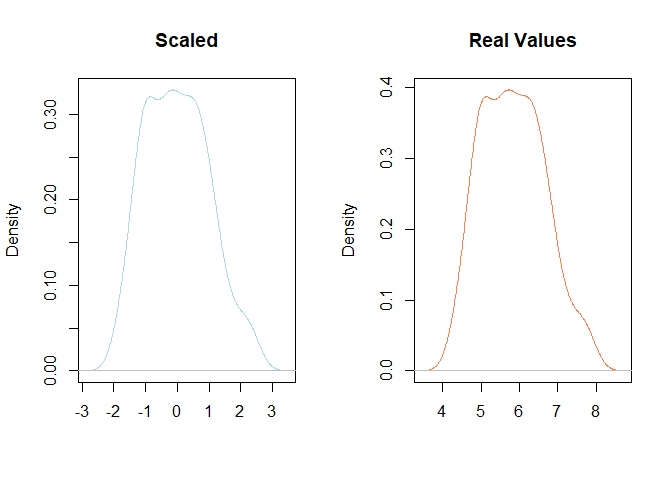

```r
#set parameters to output plots
par(mfrow=c(1,2))

#plot both distributions as denisties
plot(density(iris_standard[,1]), main = "Scaled",col="lightblue",xlab="")
plot(density(iris[,1]), main= "Real Values",col="coral",xlab="")
```

The standard deviations of the scaled variable now will be 1. Since the scaled values reflect the number of standard deviations away from the mean, running sd() on any of the numeric variables will give the identifity of standard deviation. You can see above that the two distributions are identical, where the scaled one, left, is centered at 0.

### 2b.

Create a scatter plot of the width measurements, and then, separately, a scatter plot of the length measurements. Did you find any correlations?

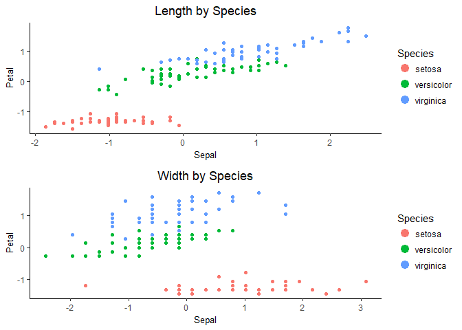

```r
#change back numeric variables form factors
par(mfrow=c(1,2))

plot_clust_1 <- ggplot(iris_standard, aes(x=Sepal.Length, y = Petal.Length, color= as.factor(Species)))+
  mytheme+
  geom_point()+
  scale_fill_manual(values=c("#CC6666", "#9999CC", "#66CC99"))+
  labs(title ="Length by Species", x ="Sepal", y="Petal")+
  guides(colour = guide_legend(title = "Species",
                               override.aes = list(size = 4)))

plot_clust_2 <- ggplot(iris_standard, aes(x=Sepal.Width, y = Petal.Width, color= as.factor(Species)))+
  mytheme+
  geom_point()+
  scale_fill_manual(values=c("#CC6666", "#9999CC", "#66CC99"))+
  labs(title ="Width by Species", x ="Sepal", y="Petal")+
  guides(colour = guide_legend(title = "Species",
                               override.aes = list(size = 4)))

grid.arrange(plot_clust_1,plot_clust_2)
```

### 2c.

Construct the K-means algorithm using *kmeans()* function on the standardized dataset with the *k* value of 3.

```r
#use k-fold validation to fix cluster assignments by setting nstart
irirs_st_clust <- kmeans(iris_standard[,num_col], centers = 3,nstart = 10)

iris_standard$Cluster<- factor(irirs_st_clust$cluster,levels = 1:3)

#find centroids for clusters
Length_centers<- irirs_st_clust$centers[,c("Sepal.Length", "Petal.Length")]%>% as.data.frame()
Width_centers<- irirs_st_clust$centers[, c("Sepal.Width", "Petal.Width")]%>% as.data.frame()

allcenters<-cbind(Length_centers, Width_centers)
allcenters$Species<-as.character(1:3)

#find centroids for species
iris_act_centers<- iris_standard[,1:5]%>%group_by(Species)%>%summarise_all(mean)
allcenters<- full_join(iris_act_centers, allcenters)

#calculate difference between centroids
diffs<- as.matrix(dist(allcenters[,2:4]))

#pair clusters to species groups based on closest centroid
pairs<- data.frame("Species"=iris_act_centers$Species, "Cluster"=as.character(1:3))
for (i in 1:3){
  pairs[i,2]<- which(exp(diffs[-i,i])==  min(exp(diffs[-i,i])))-2
}

#reorder species by cluster
pairs<- pairs%>%arrange(Cluster)


#reorder levels of species for plotting and pairing colors
iris_standard$Species<-factor(iris_standard$Species, levels = as.character(pairs$Species))

kable(pairs)
```

| Species | Cluster |
| --- | --- |
| virginica | 1 |
| setosa | 2 |
| versicolor | 3 |

2d. Inspect the output: i) Calculate the total within-cluster variance. ii) Visualize the results against the truth. iii). Plot the cluster centers over the data for both width and length.

```r
within_clust<- iris_standard%>%
  group_by(Cluster)%>%
  select(which(num_col), Cluster)%>%
  summarise_all(.funs = c(var))

Species_var<- iris_standard%>%
  group_by(Species)%>%
  select(which(num_col), Species)%>%
  summarise_all(.funs = c(var))

within_clust$Cluster<-factor(within_clust$Cluster, levels = c(2,3,1))
within_clust<- within_clust%>%arrange(Cluster)
```

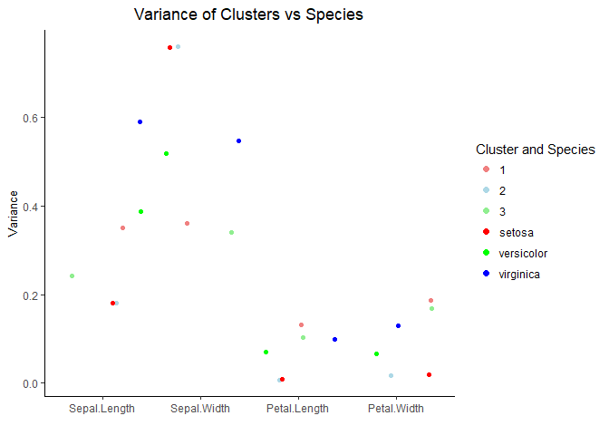

```r
ggplot()+
  mytheme+
  geom_jitter( data=melt(within_clust,id.vars="Cluster" ) , aes( x=variable, y = value, col=Cluster))+
  geom_jitter( data=melt(Species_var,id.vars="Species" ) , aes( x=variable, y = value, col=Species))+   scale_color_manual(values=c("lightcoral", "lightblue","lightgreen", "red", "green", "blue"))+
  labs(title="Variance of Clusters vs Species", x="", y="Variance")+
  guides(colour = guide_legend(title = "Cluster and Species",
                               override.aes = list(size = 2)))
```

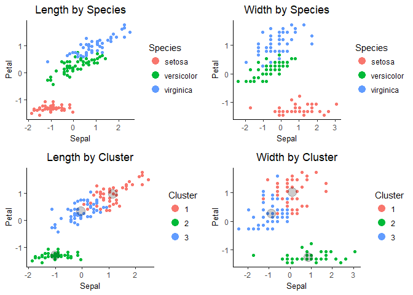

```r
Length_centers<- irirs_st_clust$centers[,c("Sepal.Length", "Petal.Length")]%>% as.data.frame()
Width_centers<- irirs_st_clust$centers[, c("Sepal.Width", "Petal.Width")]%>% as.data.frame()

plot_clust_3 <- ggplot()+
  mytheme+
  geom_point(data=iris_standard, aes(x=Sepal.Length, y = Petal.Length, color= Cluster))+
  geom_point(data= Length_centers, aes(x=Sepal.Length, y=Petal.Length ), alpha = .2, size=5)+
  scale_fill_manual(values=c("#CC6666", "#9999CC", "#66CC99"))+
  labs(title ="Length by Cluster", x ="Sepal", y="Petal")+
  guides(colour = guide_legend(title = "Cluster",
                               override.aes = list(size = 4)))

plot_clust_4 <- ggplot()+
  mytheme+
  geom_point(data= iris_standard, aes(x=Sepal.Width, y = Petal.Width, color= Cluster))+
  geom_point(data= Width_centers, aes(x=Sepal.Width, y=Petal.Width), alpha = .2, size=5)+
 scale_fill_manual(values=c("#CC6666", "#9999CC", "#66CC99"))+
  labs(title ="Width by Cluster", x ="Sepal", y="Petal")+
  guides(colour = guide_legend(title = "Cluster",
                               override.aes = list(size = 4)))

grid.arrange(plot_clust_1, plot_clust_2, plot_clust_3, plot_clust_4)
```

### 2e. Create the scree plot (via “elbow” method; sum of within-cluster variance vs. *k* value with k ranging from 1 to 10). Determine the plausible number of clusters and explain your reasons.

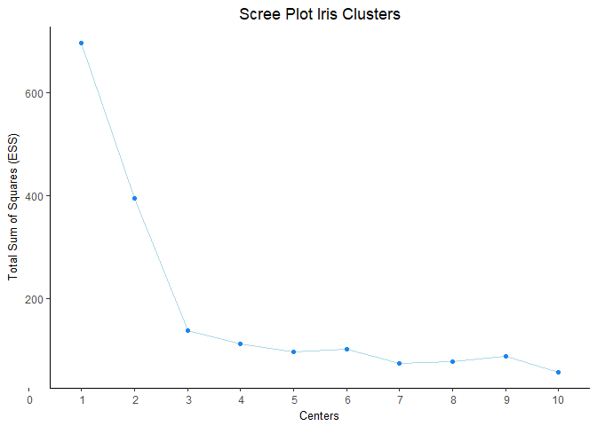

```r
tot.withinss<- c()
for(i in 1:10){
  irirs_st_clust_test <- kmeans(iris_standard[,num_col], centers = i)
  tot.withinss[i]<- irirs_st_clust_test$tot.withinss
}

scree<- data.frame(1:10,tot.withinss)
names(scree)<- c("centers","tot.withinss")
ggplot(scree, aes(x=centers, y=tot.withinss))+
  mytheme+
  geom_line(col="lightblue")+
  geom_point(col="dodgerblue2")+
  labs(title="Scree Plot Iris Clusters", x="Centers",y= "Total Sum of Squares (ESS)")+
  scale_x_discrete(limits=c(0: 10))
```

```r
second_d<- c(NA,NA,diff(diff(scree$tot.withinss)))

set_center<- which(max(second_d, na.rm = T)==second_d)
```

There are a few different ways to identify the appropriate number of centers. Most choose to use visual intuition however I wanted to quantify my decision. To do this I decided to maximize the second derivative of the Total Explained Sum of Squares (ESS). This will show me where the proportional benefits of adding clusters is maximized. I found that 4, was the optimal number of centers.

## Question 3: Hierarchical Clustering (25 points)

The *nutrient* dataset contains the measurements of nutrients in several types of meat, fish, and fowl. We can characterize the nutrients of types of food. In this example, we are going to group the foods by the common nutrient characteristics using the Hierarchical Clustering method, *hclust()* and *cutree()* functions.

### 3a. Load the **flexclust** library and the *nutrient* dataset. Print the first 5 rows.

```r
kable(head(nutrient,5))
```

|  | energy | protein | fat | calcium | iron |
| --- | --- | --- | --- | --- | --- |
| BEEF BRAISED | 340 | 20 | 28 | 9 | 2.6 |
| HAMBURGER | 245 | 21 | 17 | 9 | 2.7 |
| BEEF ROAST | 420 | 15 | 39 | 7 | 2.0 |
| BEEF STEAK | 375 | 19 | 32 | 9 | 2.6 |
| BEEF CANNED | 180 | 22 | 10 | 17 | 3.7 |

### 3b. Scale the data and calculate the pairwise distances between the observations. Explain why we need to scale the data.

```r
#scale the data by standardize method, normalization also use dto scale however is ctransformed to be between 0-1.
nutrient<-nutrient %>% scale()%>%as.data.frame()

#calculate pairwise distance between the observations
nutrient_dist<- dist(nutrient)
```

*Why scale?* Scaling data removes units of measure making it easier to compare numeic variables. This is also very important fro multivariate analysis using various methods including unsupervided ML methods. This helps because numeric variables are measured using different scales and therefore have different contributions to the analysis. This scaling standardizes the range and variability of each variable.

### 3c. Create separate dendrograms using the following linkages: **single**, **complete**, and **average**.

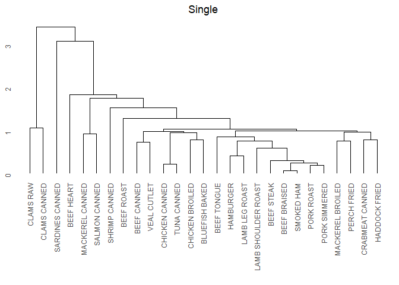

```r
#looking for ggplot hclust plot
nut_s_hc <- nutrient_dist %>% hclust(method = "single")
nut_c_hc <- nutrient_dist %>% hclust(method = "complete")
nut_a_hc <- nutrient_dist %>% hclust(method = "average")

nut_den_s <- nut_s_hc %>% ggdendrogram() + labs(title="Single")
nut_den_c <- nut_c_hc %>% ggdendrogram() + labs(title="Complete")
nut_den_a <- nut_a_hc %>% ggdendrogram() + labs(title="Average")

nut_den_s
```

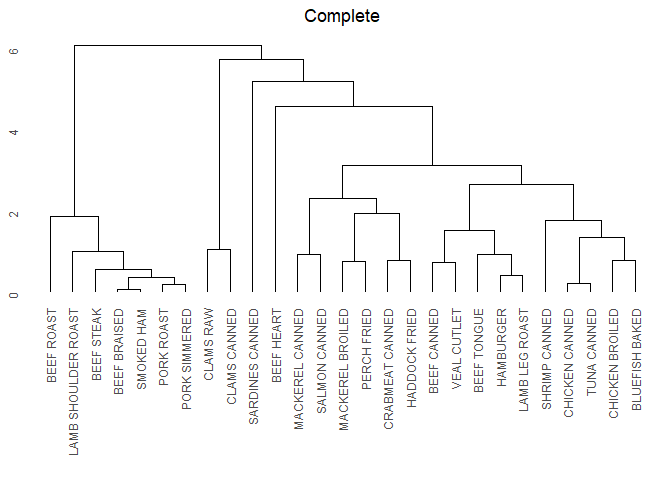

```r
nut_den_c
```

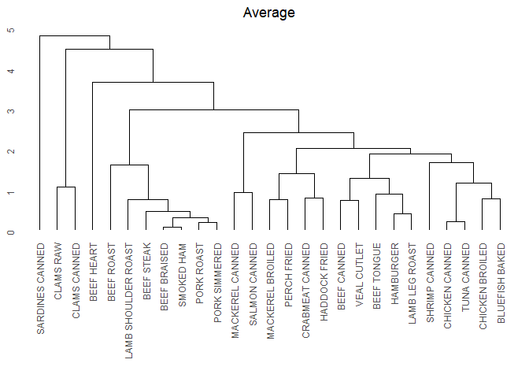

```r
nut_den_a
```

### 3d. Cut each of the dendrograms into groups of 5 and display them in plots.

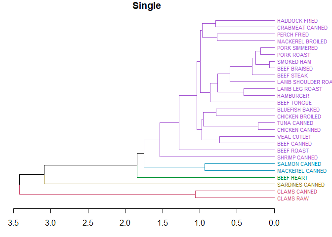

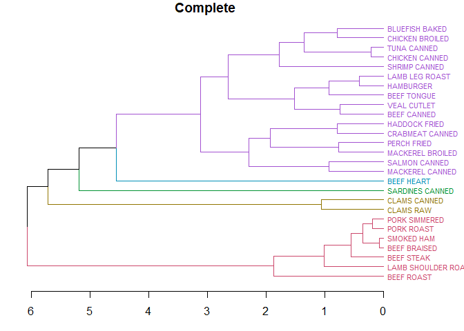

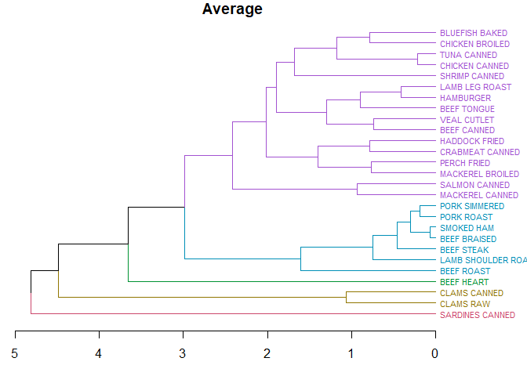

```r
dens<- list(nut_s_hc,nut_c_hc,nut_a_hc)
titles<- c("Single", "Complete", "Average")

for(i in 1:length(dens)){
par(mar=c(3,1,1,5))
dens[[i]] %>%
  as.dendrogram %>%
  set("branches_k_color", k=5) %>%
  set("labels_cex", c(.7)) %>%
  set("labels_colors",k=5) %>%
  plot(horiz=T, main= titles[i])
}
```

```r
#create cluster assignments
nutrient$Single_clust <-  as.factor(nut_s_hc %>% cutree(k=5))
nutrient$Complete_clust <-  as.factor(nut_c_hc %>% cutree(k=5))
nutrient$Average_clust <-  as.factor(nut_a_hc %>% cutree(k=5))

# bring in row names and re organize columns
nutrient<- nutrient%>%
  mutate(Type= row.names(nutrient))
nutrient<- nutrient[,c(9,1:8)]

#create subset of data for plotting
sub_nutrient<- nutrient%>%
  select(1:9)%>%
  gather(key= method, value = clusters, -1, -2, -3,-4,-5,-6)
```

### 3e. Visualize the groups in the dendrogram.

```r
#Create aggregated statistics for visual tables
z<-c("Single_clust","Complete_clust","Average_clust")

sub_nutrient%>% filter(method==z[1])%>%
    select(-method,-Type)%>%
    group_by(clusters)%>%
    summarize_all(mean)%>%
    kable(caption = z[1])
```

Single_clust

| clusters | energy | protein | fat | calcium | iron |
| --- | --- | --- | --- | --- | --- |
| 1 | 0.2420501 | 0.1680002 | 0.2152681 | -0.3595626 | -0.2610553 |
| 2 | -0.4684165 | 1.6464016 | -0.7534384 | -0.3839719 | 2.4077916 |
| 3 | -1.4811842 | -2.3520023 | -1.1087718 | 0.4361807 | 2.2709276 |
| 4 | -0.6907314 | -0.5880006 | -0.5757717 | 1.4613715 | -0.7742951 |
| 5 | -0.2708033 | 0.7056007 | -0.3981050 | 4.1396825 | 0.0811046 |

```r
sub_nutrient%>% filter(method==z[2])%>%
    select(-method,-Type)%>%
    group_by(clusters)%>%
    summarize_all(mean)%>%
    kable(caption = z[2])
```

Complete_clust

| clusters | energy | protein | fat | calcium | iron |
| --- | --- | --- | --- | --- | --- |
| 1 | 1.4371395 | -0.1008001 | 1.4800859 | -0.4517078 | 0.0224486 |
| 2 | -0.3973993 | 0.1911002 | -0.4369696 | -0.0916324 | -0.4492432 |
| 3 | -0.4684165 | 1.6464016 | -0.7534384 | -0.3839719 | 2.4077916 |
| 4 | -1.4811842 | -2.3520023 | -1.1087718 | 0.4361807 | 2.2709276 |
| 5 | -0.2708033 | 0.7056007 | -0.3981050 | 4.1396825 | 0.0811046 |

```r
sub_nutrient%>% filter(method==z[3])%>%
    select(-method,-Type)%>%
    group_by(clusters)%>%
    summarize_all(mean)%>%
    kable(caption = z[3])
```

Average_clust

| clusters | energy | protein | fat | calcium | iron |
| --- | --- | --- | --- | --- | --- |
| 1 | 1.4371395 | -0.1008001 | 1.4800859 | -0.4517078 | 0.0224486 |
| 2 | -0.3973993 | 0.1911002 | -0.4369696 | -0.0916324 | -0.4492432 |
| 3 | -0.4684165 | 1.6464016 | -0.7534384 | -0.3839719 | 2.4077916 |
| 4 | -1.4811842 | -2.3520023 | -1.1087718 | 0.4361807 | 2.2709276 |
| 5 | -0.2708033 | 0.7056007 | -0.3981050 | 4.1396825 | 0.0811046 |

```r
#Create matrix to use for heatmap
m<-c()
for(i in 1:3) {
  m <- cbind(m, sub_nutrient %>%
               filter(method==z[i]) %>%
               group_by(clusters)%>%
               select(energy,protein,fat,calcium,iron) %>%
               summarise_all(mean)%>%
               select(2:6)%>%
               as.matrix())
}
```

### 3f. Discuss the common nutrient characteristics in each group.

```r
#change names to identify which method belong to which values
colnames(m) <- paste0(c(rep("Single_clust",5),rep("Complete_clust",5),rep("Average_clust",5)),"_",colnames(m))

#scale margin for output
margin <- list(l = 50, r = 50, b = 120, t = 100, pad = 4)

#plot heatmap
heat_plot_s <- plot_ly(
    x = capitalize(colnames(m)), y = as.character(1:5),
    z = m, colorscale = "Greys",type = "heatmap") %>%
  layout(title = 'Single_clust Nutrient Characteristics by Cluster',
         xaxis =list(title = "Nutrient Characteristics"), yaxis =list(title = "Cluster"),margin=margin)
heat_plot_s
```

[interactive chart not shown]

Cluster 5 appears to be the same across methods with very high calcium, cluster 3 in method “single” is most simliar to cluster 4 in both “complete” and “average”. Cluster 1 for both “complete” and “average” methods also appear to be similar.

## Question 4: Logistic Regression (25 Points)

Load the **Sleuth2** library and the *case2002* dataset. This dataset reports results of a survey conducted from 1972 to 1981 in the Netherlands aiming to see if birdkeeping is a risk factor for lung cancer. Variables include whether or not an individual had lung cancer, whether or not they were birdkeeping, their gender, socioeconomic status, age, years of smoking, and average rate of smoking.

### 4a. Perform basic EDA comment on the scatterplots of the continuous variables colored by whether or not an individual had lung cancer.

```r
#assign training index
train<- sample(1:nrow(case2002),100)

#sacle data through standardization
case2002[,5:7]<- scale(case2002[,5:7])

#convert to factor other binary categorical variables columns 1:4
for(i in 1:4){
  case2002[i] <- as.factor(case2002[,i])
}
```

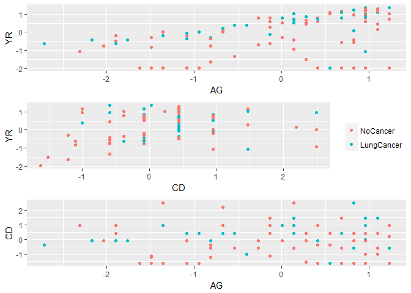

```r
#option 4, best visualization for this question
scatplot_1<- case2002[train,]%>%
  ggplot(aes(x=AG,y=YR, color=factor(LC)))+
    geom_point()+
    theme(legend.position = "none")

scatplot_2<- case2002[train,]%>%
  ggplot(aes(x=CD,y=YR, color=factor(LC)))+
    geom_point()+
    guides(colour = guide_legend(title = NULL))

scatplot_3<- case2002[train,]%>%
  ggplot(aes(x=AG,y=CD, color=factor(LC)))+
    geom_point()+
    theme(legend.position = "none")

grid.arrange(
  scatplot_1,scatplot_2,scatplot_3)
```

### 4b. Fit a logistic regression predicting an individual has lung cancer that includes all variables in the model. Compute the model’s Mean Squared Error on the testing set.

```r
for(i in 1:4){
case2002[,i] <- as.factor(as.numeric(case2002[,i])-1)
}
 # 1= LungCaner, 0= NoCancer
 # 1= Female,    0= Male
 # 1= High,      0= Low
 # 1= Bird,      0= NoBird


#model 1
log_mod_1 <- glm(formula = LC~., family = binomial(),data = case2002[train,])
log_pred_1 <- predict(object = log_mod_1, case2002[-train,],type="response")
mse_mod_1<-mean((as.numeric(case2002$LC[-train]) - 1 -log_pred_1)^2)
print(paste("The Mean Squared Error (MSE) for model 1 is",round(mse_mod_1,digits = 3)))
```

```
## [1] "The Mean Squared Error (MSE) for model 1 is 0.209"
```

### 4c. Fit a logistic regression predicting an individual has lung cancer that includes all variables in the model except socioeconomic status. Compute the model’s Mean Squared Error on the testing set.

```r
log_mod_2 <- glm(formula = LC~., family = binomial(),data = case2002[train,-3])
log_pred_2 <- predict(object = log_mod_2,case2002[-train,],type="response")
mse_mod_2 <- mean((as.numeric(case2002$LC[-train])- 1 - log_pred_2)^2)
print("The Mean Squared Error (MSE) for model 2 is",mse_mod_2)
```

```
## [1] "The Mean Squared Error (MSE) for model 2 is"
```

### 4d. Fit a logistic regression predicting an individual has lung cancer based on socioeconomic status and the number of years that the person has smoked. Compute the model’s Mean Squared Error on the testing set.

```r
log_mod_3 <- glm(formula = LC~SS+YR, family = "binomial",data = case2002[train,])
log_pred_3 <- predict(object = log_mod_3,case2002[-train,],type="response")
mse_mod_3 <- mean((as.numeric(case2002$LC[-train]) - 1 - log_pred_3)^2)
print("The Mean Squared Error (MSE) for model 3 is",mse_mod_3)
```

```
## [1] "The Mean Squared Error (MSE) for model 3 is"
```

```r
#include on last model based on anova results from 4b
log_mod_4 <- glm(formula = LC~BK+YR, family = "binomial",data = case2002[train,])
log_pred_4 <- predict(object = log_mod_4,case2002[-train,],type="response")
mse_mod_4 <-mean((as.numeric(case2002$LC[-train]) - 1 - log_pred_4)^2)
print("The Mean Squared Error (MSE) for model 4 is",mse_mod_4)
```

[output not shown]

```
## [1] "The Mean Squared Error (MSE) for model 4 is"
```

### 4e. Which model provides the best predictions of lung cancer status?

```r
MSE_df<-data.frame("Model"= 1:4, "MSE"=c(mse_mod_1,mse_mod_2,mse_mod_3,mse_mod_4))
MSE_df
```

```
##   Model       MSE
## 1     1 0.2086915
## 2     2 0.1846503
## 3     3 0.2250967
## 4     4 0.1925264
```

### One last thing…

I wanted to visualize the improvements on the different models using different cutoffs and accuracy.

[figure not shown]

```r
first_perf<- c()
for(i in 2:5){
first_perf[i-1]<- min(which(acur_df[,i]== max(acur_df[,i])))
}

best<- names(acur_df)[which(first_perf==min(first_perf))+1]
```